# Mejora continua (KAIZEN)

Dentro del **control de calidad** (QC), es crucial mantener y mejorar de forma continua los productos y servicios.

- Comprensión de **Kaizen** (mejora continua)
- Comprensión de la **historia del control de calidad** (QC Story)
- Comprensión de las **3M** (Muri, Muda, Mura)
- Comprensión de las **actividades de pequeños grupos**
- Comprensión del **enfoque en puntos clave** (enfoque prioritario)

[Audio_1](https://drive.google.com/file/d/1-UtpL9xHPOiTBKT5nJya0s7eYjpVsVix/view?usp=drive_link)

```python
import os

try:
  os.chdir('../Python/QCKentei4')
except:
  pass

path = os.getcwd()
path
```

```
'/Users/takanohiroshi/Library/CloudStorage/OneDrive-個人用/Documenten/Python/QCKentei4'
```

```python
from PIL import Image
```

## 03-01 KAIZEN (mejora continua)

**KAIZEN** es la acción de hacer que las cosas sean mejores y, en la gestión de la calidad, consiste en mejorar la **calidad**, los **costos**, la **productividad**, etc., de los **productos** y **servicios**.

La **mejora continua** es la repetición de las actividades de mejora. Es importante que las actividades de mejora no se realicen una sola vez, sino que repitan y se mantengan de forma continua implementando el ciclo PDCA.

La **mejora de la calidad** es la actividad en la que identificamos los problemas en el trabajo diario (la brecha entre las **situación actual** y la **situación ideal**) y los eliminamos para crear un estado mejor.

Lo más importante en las actividades de **mejora continua**, que se loga repitiendo ciclos como el **PDCA** (Planificar, Hacer, Verificar, Actuar).

[Audio_2](https://drive.google.com/file/d/1rkZupR9qE1SDO7uPa6iXii4dwr5ReHEU/view?usp=drive_link)

## 03-02 Historia del control de calidad (QC Story)

La historia del control de calidad (QC Story): es un procedimiento para llevar a cabo actividades de mejora de manera efectiva y organizada, generalmente siguiendo **ocho pasos**.

### 1. Qué es el QC Story

Se difine un **problema** como la diferencia entre el estado actual y el estado ideal, mientras que un **desafío** se define como la diferencia entre el estado actual y el estado futuro deseado.

Para actividades de resolución de problemas y logro de objetivos, se utilizan el QC Story de tipo **resolución de problemas** y el QC Story de tipo **logro de objetivos**, respectivamente

La forma de proceder es ligeramente diferente.

[Audio_3](https://drive.google.com/file/d/1ZVvuj-JbG5tMVpR_IFlGEtQiCArbfgTF/view?usp=drive_link)

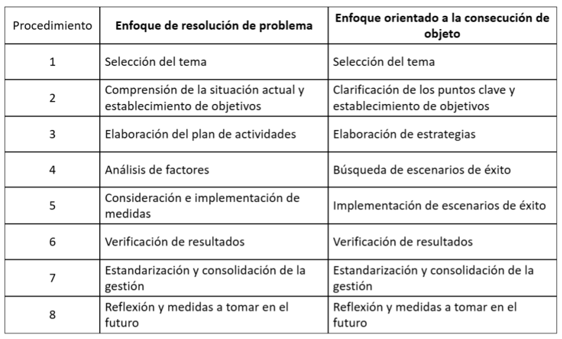

```python
img = Image.open('./Data4/QCStory.png')
display(img)
```

### 2. QC Story de resolución de problemas

Paso 1: Selección del tema

- Analizar los problemas en el lugar de trabajo y seleccionar un tema para las actividades.
- Al hacer la selección, se debe considerar la política de la empresa y la efectividad de las mejoras.
- Métodos de control de calidad efectivos
  - Gráficos, Diagrama de Pareto

Paso 2: Comprensión de la situación actual

- Evaluar la situación actual basándose en **hechos y datos**, no en **suposiciones o experiencia**, para identificar los problemas, determinar qué y cómo mejorarlo, y establecer los objetivos.
- Métodos:
  - Diagrama de Pareto, Hoja de Verificación, Gráficos, Histograma, Diagrama de Dispersión, Estratificación

- Utilizar técnicas como la **lluvia de ideas** para identificar los **factories** que se cree que influyen en el problema.
- Utilice una de las siete herramientas de control de calidad (QC), como el diagrama de causa y efecto (Diagrama de Ishikawa), para organizar los factores identificados.
- Analizar los factores identificados y determinar las medidas a tomar para los **factores criticos**.
- Métodos:
  - Diagrama de Causa-Efecto, Histograma, Gráficos, Diagrama de Dispersión, Estratificación, Gráfico de Control, Hoja de Verificación, lluvia de ideas

- Utilizando herramientas como el **diagrama de álbol** (系統図), una de las Nuevas Siete Herramientas del Control de Calidad (NQC7), se seleccionan los factores a tratar de entre los identificados en el paso 3, basándose en criterios como la efectividad, la viabilidad y el coste, y se elabora un plan de implementación de las contramedidas.
- Métodos:
  - Diagrama de árbol / Árbol de causas

Paso 5: Implementación y seguimiento de contramedidas

- Implementar las medidas definidas en el paso 4.

Paso 6: Confirmación de los efectos

- Evaluar **cuantitativamente** la efectividad de las medidas utilizando gráficos y otros recursos.
- Si no se ven los resultados deseados, se debe analizar qué falló para lograr el objetivo, y se debe regresar y repetir los pasos 3 a 5.
- Métodos:
  - Gráfico, Gráfico de Control, Hoja de Verificación, Diagrama de Pareto, Histograma

Paso 7: Estandarización y consolidación de la gestión

- Cuando se confirme la efectividad de las medidas, se deben crear **estándares de trabajo**, **listas de verificación** y otros documentos para **estandarizarlas** y así consolidar sus efectos.
- Métodos:
  - Hoja de Verificación, Gráfico de Control, Gráficos, Histograma

Paso 8: Reflexión y acciones futuras

- Reflexionar sobre los aspectos exitosos y no exitosos de la actividad de mejora para aplicarlos en la próxima actividad de mejora.

[Audio_4](https://drive.google.com/file/d/19gsTQ4UpV9ID7QWB8EHNuyHSVifyxOQz/view?usp=drive_link)

## 03-03 3M

Las 3M: Dentro de las actividades de mejora, se mencionan tres puntos de vista importantes para identificar problemas: la eliminación de Muri (sobrecarga), Mura (irregularidad) y Muda (desperdicio). Se les llama las 3M por sus iniciales.

- **Muri** (sobrecarga) se refiere a algo que es difícil de hacer o llevar a cabo, algo que resulta trabajoso o imposible.
  - Trabajos que requieren fuerza, agacharse o estirarse, o periodos prolongados de concentración, pueden llevar a Muri (sobrecarga). Esto a su vez puede causar accidentes laborales o fallos en los equipos, lo que dificultar la continuidad de una producción estable.
- **Mura** (irregularidad) se refiere a algo que es desigual, no uniforme o que tiene variaciones.
  - Las irregularidades (Mura) en el trabajo, como las diferencias de habilidad entre los trabajadores, la distribución desigual de la carga laboral, métodos de trabajo inconsistentes o tareas no programadas, pueden provocar variaciones o anomalías en la calidad, y retrasos en las entregas.
- **Muda** (desperdicio) se refiere a algo inútil o a un trabajo que no genera valor añadido.
  - La ineficiencia (Muda) en el trabajo, como malos flujos de trabajo, tiempos de espera, la necesidad de buscar piezas o la generación de residuos, puede provocar retrasos en la entrega de productos y un aumento en los costos de producción.

Un entorno de trabajo ideal es aquel en el que la carga de trabajo (cantidad de trabajo) y la capacidad están en equilibrio. Cuando este equilibrio se rompe, surgen las 3M (Muda, Mura, Muri).

Aumento en la carga de trabajo puede resultar en Muri (sobrecarga), mientras que un aumento en la capacidad puede llevar a Muda (desperdicio) de personal.

Si el equilibrio entre la carga de trabajo y la capacidad no es estable, se produce Mura (irregularidad). De esta forma, las causas de las 3M a menudo se deben a una asignación de personal o a una planificación de la producción inadecuadas,, por lo que es crucial encontrar la manera de equilibrar esta balanza.

[Audio_5](https://drive.google.com/file/d/1qiWKyoF48diDfVclNv7DBEhVDXTTVoqf/view?usp=drive_link)

## 03-04 Actividades de mejora en pequeños grupos

Actividades de mejora en pequeños grupos: son actividades de mantenimiento y mejora en las que personas con un objetivo común dentro del lugar de trabajo utilizan técnicas de Control de Calidad (QC) y otras herramientas para mejorar el conocimiento, las habilidades y la motivación de los miembros, al mismo tiempo que contribuyen al logro de los objetivos de la organización. También se les conoce como **actividades de Círculos de Calidad (QC)**.

Una de las iniciativas para la mejora continua de la calidad es la actividad de mejora en pequeños grupos (小集団改善活動).

[Audio_6](https://drive.google.com/file/d/16FnJsR9TQg8aZ_uYAiCG1_gtXcA0uMjV/view?usp=drive_link)

## 03-05 Enfoque en lo importante

Enfoque en lo importante: es una filosofía que, para la resolución de problemas, prioriza abordar aquellos que tienen un mayor impacto en los resultados, incluso si son difíciles de resolver, en lugar de comenzar con los más fáciles.

### 1. Enfoque en lo importante

Al intentar abordar todos los problemas en una actividad de mejora, a veces terminamos dejando todas las actividades a medias, lo que las hace ineficaces. Abordar primero las soluciones superficiales que no atacan la causa raíz tampoco conducirá a una mejora significativa. Es más efectivo dar alta prioridad a las mejoras con mayor impacto y abordarlas en ese orden, incluso si son díficiles de resolver. Este enfoque de concentrar los esfuerzos de mejora en las áreas con mayor impacto y más importantes se conoce como "**pensamiento de enfoque**"（重点指向）

### 2. Diagrama de Pareto

Para el pensamiento de enfoque, se utiliza a menudo el análisis de Pareto, que se basa en el **diagrama de Pareto**. Un diagrama de Pareto es un gráfico combinado que presenta un gráfico de barras, donde los valores de fallos o defectos de un producto están ordenados de mayor a menor, y un gráfico de líneas que muestra el porcentaje acumulado de esos valores. El diagrama de Pareto permite identificar qué elementos causan la mayoría de los problemas de no conformidad o fallos, y cuál es la magnitud de su impacto.

[Audio_7](https://drive.google.com/file/d/1LB6ifB6BkYM6PaIrfCgBcfsnL19EZH2Z/view?usp=drive_link)

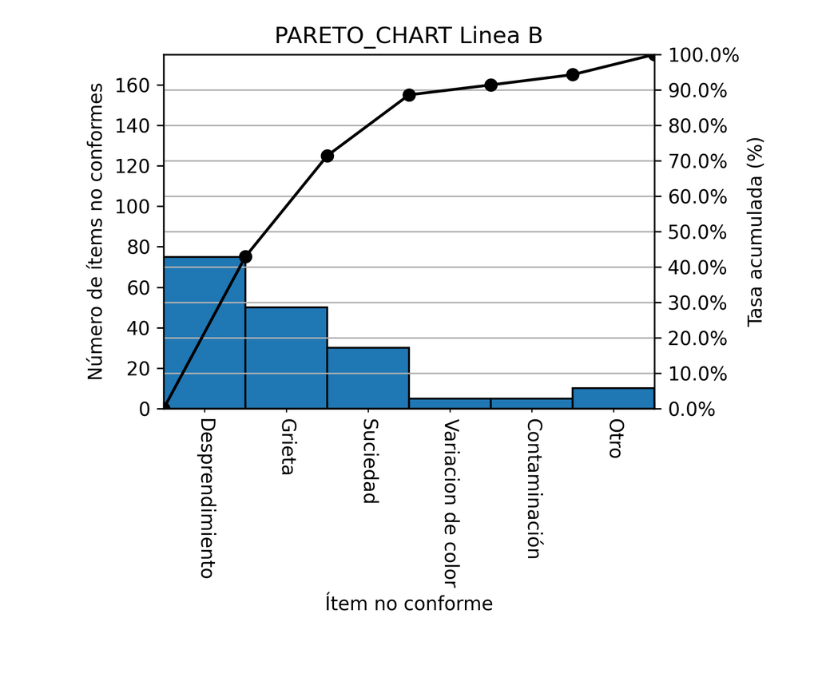

```python
img = Image.open('./Data4/Pareto_Chart.png')
display(img)
```

### 3. Principio de Pareto / Ley de Pareto

Como se muestra en el diagrama, aunque haya muchos elementos de clasificación, a menudo son los 2 o 3 principales los que tienen un gran impacto, y a esto se le llama la **Ley de Pareto**.

La **Ley de Pareto** es el **principiio** que establece que, en cualquier conjunto, un pequeño número de elementos es responsable de la mayor parte del impacto o efecto total.

El hecho de que un pequeño número de causas sea responsable de la mayor parte de los resultados en los problemas laborales significa que, si se resuelven esas pocas causas, la mayor parte de los problemas se solucionarán.

En las actividades de mejora, es crucial enfocarse en las medidas con mayor impacto para utilizar de la forma más efectiva los recursos como las personas, el tiempo y el dinero.

Ejemplos en los que aplica la Ley de Pareto son:

- El 70-80% de las ventas provienen del 20-30% de los clientes principales.
- El 70-80% de las ventas se genera a partir del 20-30% del total de productos.
- El 70-80% de los resultados del trabajo se obtienen en el 20-30% del tiempo total invertido.

[Audio_8](https://drive.google.com/file/d/1BxKocfrlCw6IoP18YnM_fc3g8fF7-uuk/view?usp=drive_link)

```python
from IPython.display import display
from PIL import Image
import gdown
import re

def get_file_id(url,out):
    # 正規表現でファイルIDを抽出
    match = re.search(r'/d/([a-zA-Z0-9_-]+)', url)

    if match:
        file_id = match.group(1)
        print("ファイルID:", file_id)
    else:
        print("ファイルIDが見つかりませんでした。")

    url = f"https://drive.google.com/uc?id={file_id}"

    output = out

    gdown.download(url, output, quiet=False)

    img = Image.open(out)
    display(img)
```

```
ファイルID: 1GNzKFSsn8fruJWX3F3sL2BLnNLLJs0rF
```

```
Downloading...
From: https://drive.google.com/uc?id=1GNzKFSsn8fruJWX3F3sL2BLnNLLJs0rF
To: /Users/takanohiroshi/Library/CloudStorage/OneDrive-個人用/Documenten/Python/QCKentei4/Data4/QCStory.png
```

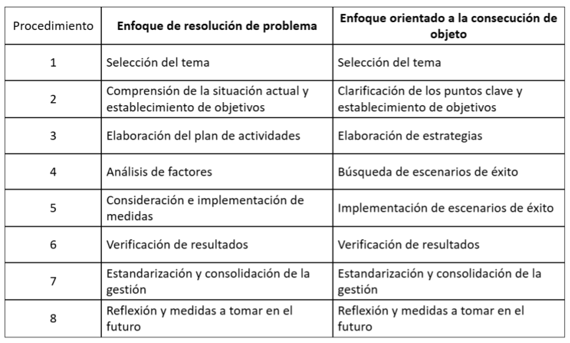

```python
url= 'https://drive.google.com/file/d/1GNzKFSsn8fruJWX3F3sL2BLnNLLJs0rF/view?usp=drive_link'
out = './Data4/QCStory.png'
get_file_id(url,out)
```

```
ファイルID: 17uxeb-uLvPuSiiuSiqdbGbXmaDmm1ZpQ
```

```
Downloading...
From: https://drive.google.com/uc?id=17uxeb-uLvPuSiiuSiqdbGbXmaDmm1ZpQ
To: /Users/takanohiroshi/Library/CloudStorage/OneDrive-個人用/Documenten/Python/QCKentei4/Data4/Pareto_Chart.png
```

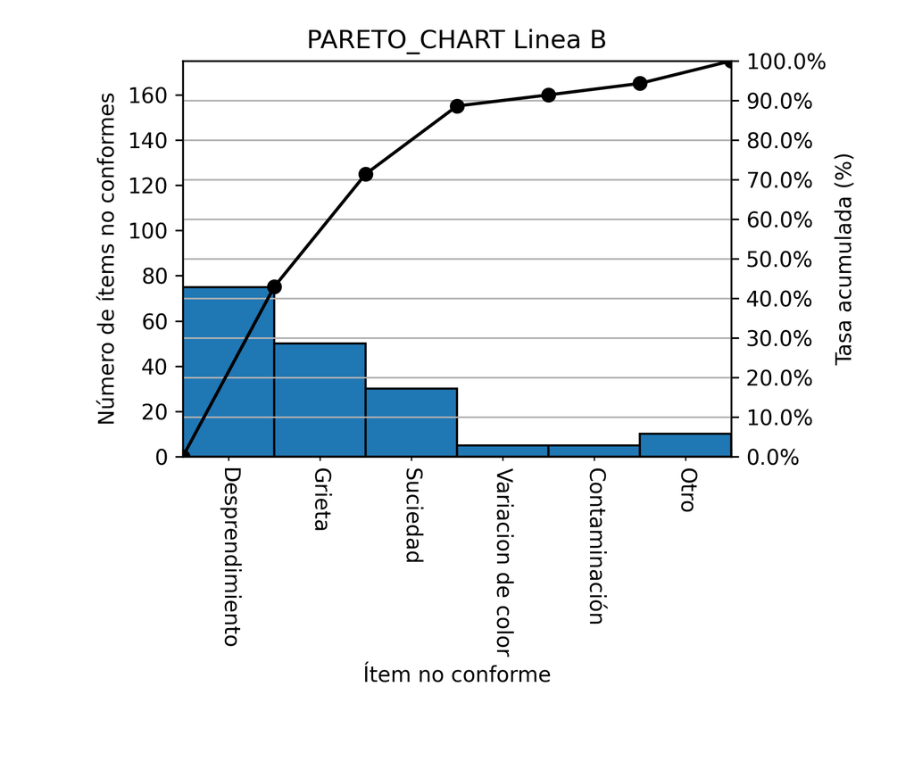

```python
url= 'https://drive.google.com/file/d/17uxeb-uLvPuSiiuSiqdbGbXmaDmm1ZpQ/view?usp=drive_link'
out = './Data4/Pareto_Chart.png'
get_file_id(url,out)
```

```python
notebook_name = 'QCKentei4-3.ipynb'
notebook_name_html = notebook_name.replace(".ipynb",".html")

!jupyter nbconvert --to html {notebook_name}
```

```
[NbConvertApp] Converting notebook QCKentei4-3.ipynb to html
[NbConvertApp] Writing 1850998 bytes to QCKentei4-3.html
```